# FigureYa15 WGCNA

小丫画图

2018.6.28

微信ID: epigenomics E-mail: epigenomics@rainbow-genome.com

本代码作者：TSS，他来自生信菜鸟团

小丫编译用法、校验代码

### 需求描述

用R代码画出paper里的WGCNA结果图、同一模块内部的基因表达谱拟合，输出模块基因表达谱，用于绘制heatmap和功能富集分析。

例子一：这篇paper里的WGCNA结果图

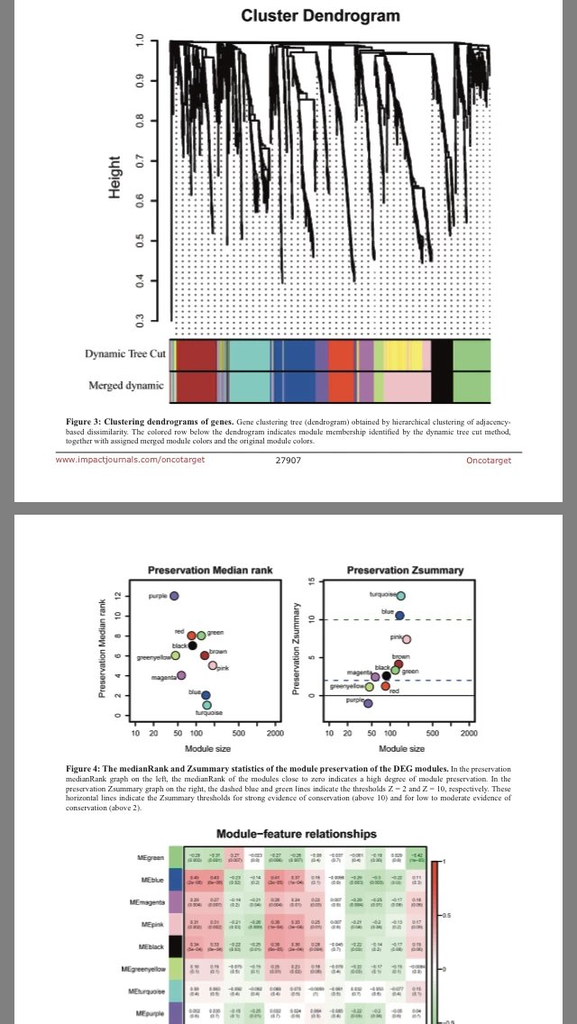

出自https://doi.org/10.18632/oncotarget.15842

例子二：用WGCNA找出gene module，用拟合的方式，展示每个module里的基因表达谱。

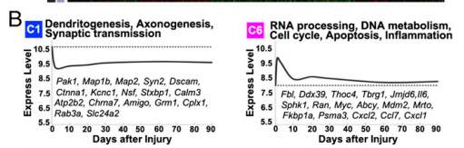

出自http://www.pnas.org/content/112/43/13360

例子三：用WGCNA找出的module画热图。把各个module的基因作为文件输出，将用于代码9或代码17的输入文件。

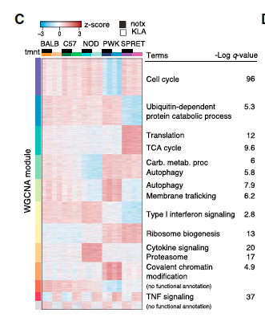

出自https://www.cell.com/cell/abstract/S0092-8674(18)30511-7

### 应用场景

不需要筛差异表达基因，直接从全基因组找表达谱相似的gene组成的gene module（模块）。尤其适合样本量超过15的高通量测序数据。

用于研究表型的差异是由哪些gene决定的，例如找出决定不同发育阶段、疾病亚型、药物处理反应的关键基因module，进而鉴定新的biomarkers或治疗靶标。

借鉴文章里的应用方案：

#### 方案一：找gene module作为biomarker

例子一的paper用TCGA的papillary renal cell carcinoma (PRCC) RNA-seq数据找出差异表达基因，用WGCNA找出11个共表达的基因模块。其中蓝色模块与病理状态高度相关（r=0.45），其功能富集在nuclear division, cell cycle phase, and spindle。蓝色模块中的40个关键基因可以区分癌症亚型，有望用做biomarker。

#### 方案一：用拟合的曲线展示各gene module的基因表达谱

例子二的paper，用每个module排名前30基因的均值拟合表达谱曲线。

#### 方案二：用热图和表格展示gene module-表达谱-功能-表型的关系

例子三左边的热图是用module里的gene画的，每个module就相当于大家熟悉的热图里的cluster，因此，不用再做聚类。

右侧的富集分析表格的做法：先为每个module里的基因做功能富集分析；然后取排名第一的通路的term，粘贴到该module热图的右侧。

### 输入数据的预处理

输入数据是12219个TPM > 1的基因在20个sample里的TPM。包括5种细胞、2种处理、2次重复。

数据来源：https://www.cell.com/cms/attachment/2119342979/2092476184/mmc2.xlsx

```r
mydata= read.csv("easy_input_exp.csv",row.names = 1)
dim(mydata)
```

```
## [1] 12219    20
```

```r
#此处用head(mydata)看出行名是基因名，第1列至第20列是基因在20个sample里的表达量
head(mydata)
```

```
##           TPM_BALB_notx_rep1 TPM_BALB_notx_rep2 TPM_BALB_KLA_rep1
## NM_010239          22062.870          25677.391         19762.789
## NM_010240          18045.086          15463.928         15733.634
## NM_007393           9679.471           8695.588          8977.449
## NM_017372          11088.079          10541.113          9827.576
## NM_021278           8976.383           5154.037          8339.677
## NM_009983          11438.979          13926.371          9626.801
##           TPM_BALB_KLA_rep2 TPM_C57_notx_rep1 TPM_C57_notx_rep2
## NM_010239         23106.775         23129.373         29526.056
## NM_010240         14341.678         18324.906         14821.064
## NM_007393          8016.248         11655.336         10446.086
## NM_017372          9485.170          8062.960          9063.045
## NM_021278          4604.613         10002.415          6330.707
## NM_009983         12320.499          7945.476          8294.304
##           TPM_C57_KLA_rep1 TPM_C57_KLA_rep2 TPM_NOD_notx_rep1
## NM_010239        21590.220        24591.640         31148.186
## NM_010240        15284.989        12599.083         13224.029
## NM_007393        10977.044         9496.427         19388.608
## NM_017372         6708.213         7604.788         31073.087
## NM_021278         8813.137         6147.731         13503.457
## NM_009983         6671.063         6847.422          7582.024
##           TPM_NOD_notx_rep2 TPM_NOD_KLA_rep1 TPM_NOD_KLA_rep2
## NM_010239         26140.726        30749.928        26045.324
## NM_010240         11238.109        11139.992        10052.458
## NM_007393         17261.609        17579.981        16738.774
## NM_017372         30558.663        26071.233        25208.023
## NM_021278         17894.955        11680.977        14323.658
## NM_009983          5557.777         6592.688         5016.852
##           TPM_PWK_notx_rep1 TPM_PWK_notx_rep2 TPM_PWK_KLA_rep1
## NM_010239         52546.020         62393.491        45654.937
## NM_010240          6528.345          4191.959         4858.093
## NM_007393         10449.326          7014.896        10420.657
## NM_017372          2647.076          2295.951         2172.992
## NM_021278          4725.131          2722.223         3747.145
## NM_009983          7879.051          8167.536         6429.948
##           TPM_PWK_KLA_rep2 TPM_SPRET_notx_rep1 TPM_SPRET_notx_rep2
## NM_010239        56710.154           33710.237           34144.603
## NM_010240         3796.167            6159.091            7361.568
## NM_007393         7105.237           12682.475           11865.027
## NM_017372         2076.417            6253.887           11811.606
## NM_021278         2633.417            6867.520            6298.906
## NM_009983         6778.878            4389.357            6387.591
##           TPM_SPRET_KLA_rep1 TPM_SPRET_KLA_rep2
## NM_010239          27430.000          30802.967
## NM_010240           5091.249           6287.347
## NM_007393          11276.972          10033.205
## NM_017372           5351.482          10422.595
## NM_021278           6838.387           5892.991
## NM_009983           3596.006           5292.230
```

```r
#如果你的sample比较多，几十上百个的，推荐用fix函数来查看，MAC系统可能要另外安装XQuartz。运行下面这行来代替head(mydata)
#fix(mydata)
```

转置，也就是行变成列，列变成行

```r
datExpr0 = data.frame(t(mydata))
colnames(datExpr0) <- rownames(mydata)
rownames(datExpr0) <- colnames(mydata)
```

这套数据的作者用的是TPM > 1的所有基因，如果你也想这样做，就先运行下面这行代码，跳过“筛选方差前25%的基因”，直接进入下一部分。

```r
datExpr1<-datExpr0
```

#### 筛选方差前25%的基因

输入数据的作者选取的是TPM>1的基因作为WGCNA的输入。基因数量较多，对电脑要求高。为了便于大家在自己的电脑上操作本套代码，此处挑选了变化较大的前25%的基因。

用前25%的基因会比用全部基因找出来的module数量少。

```r
m.vars=apply(datExpr0,2,var)
expro.upper=datExpr0[,which(m.vars>quantile(m.vars, probs = seq(0, 1, 0.25))[4])]
datExpr1<-data.matrix(expro.upper)
```

#### 判断是否有不好的sample或gene

先检查是否有哪个sample或基因表达量缺失，定义成不好的sample或gene

```r
library(WGCNA)
gsg = goodSamplesGenes(datExpr1, verbose = 3);
```

```
##  Flagging genes and samples with too many missing values...
##   ..step 1
```

```r
gsg$allOK
```

```
## [1] TRUE
```

如果这里返回的结果是`TRUE`，说明所有基因都通过了检查。

如果你用全部基因作为输入，很有可能返回`FALSE`，说明存在不好的基因或sample。

下面的代码就会去除那些不好的基因或sample。

#### 去除不好的sample或gene

```r
if (!gsg$allOK){
  # Optionally, print the gene and sample names that were removed:
  if (sum(!gsg$goodGenes)>0)
     printFlush(paste("Removing genes:", paste(names(datExpr0)[!gsg$goodGenes], collapse = ", ")));
  if (sum(!gsg$goodSamples)>0)
     printFlush(paste("Removing samples:", paste(rownames(datExpr1)[!gsg$goodSamples], collapse = ", ")));
  # Remove the offending genes and samples from the data:
  datExpr1 = datExpr1[gsg$goodSamples, gsg$goodGenes]
}
```

#### 判断是否有离群样本

通过聚类分析，能看出是否有个别sample跟多数sample的距离较远，决定是否需要去除离群样本。

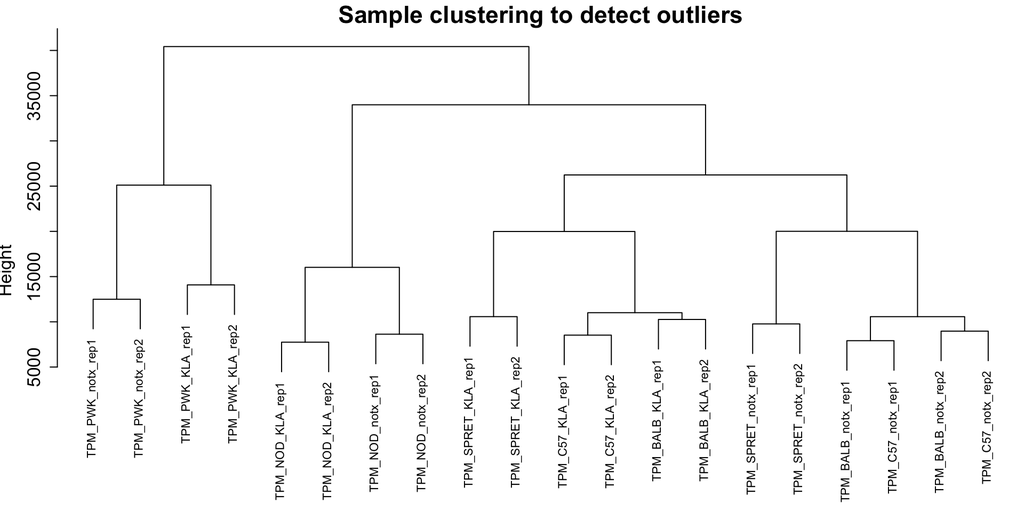

```r
sampleTree = hclust(dist(datExpr1), method = "average")
par(cex = 0.7);
par(mar = c(0,4,2,0))
plot(sampleTree, main = "Sample clustering to detect outliers", sub="", xlab="", cex.lab = 1.5,
     cex.axis = 1.5, cex.main = 2)
```

这套数据没有离群样本，不需要去除。

如果你的数据有离群样本需要去除，就运行下面这段代码。

#### 去除离群样本

例如：以35000作为cutoff，就会去除最左边的4四个sample，只剩下16个sample。

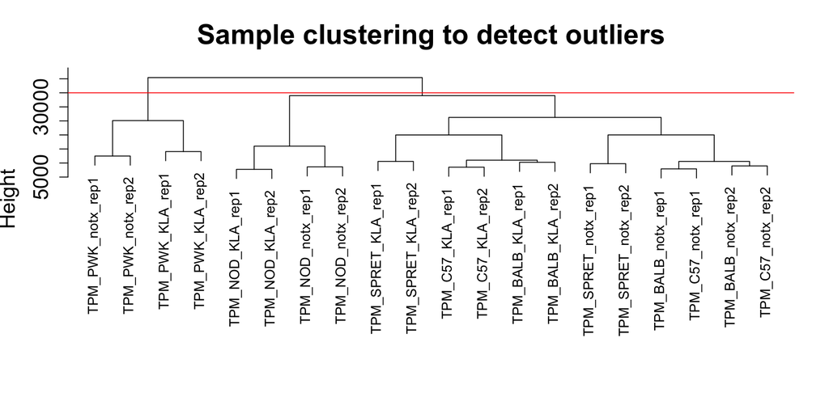

```
## integer(0)
```

```r
plot(sampleTree, main = "Sample clustering to detect outliers", sub="", xlab="", cex.lab = 1.5, cex.axis = 1.5, cex.main = 2) +
#想用哪里切，就把“h = 35000”和“cutHeight = 35000”中的“500”换成你的cutoff
abline(h = 35000, col = "red")
```

```r
clust = cutreeStatic(sampleTree, cutHeight = 35000, minSize = 10)
keepSamples = (clust==1)
datExpr = datExpr1[keepSamples, ]
nGenes = ncol(datExpr)
nSamples = nrow(datExpr)
dim(datExpr)
```

```
## [1]   16 3055
```

这套输入数据不需要去除离群样本，因此，跳过“去除离群样本”。

运行下面的代码，用全部20个样本进行后续的分析：

```r
datExpr = as.data.frame(datExpr1)
nGenes = ncol(datExpr)
nSamples = nrow(datExpr)
```

### 找gene module

WGCNA分析的关键是找gene module。先选择合适的阈值，通过构建网络找gene module，找出来的gene module可信度如何？要做Preservation，去除not preserved module。这样找出的共表达的gene module就可以用于下一步分析了。

#### 选择构建网络的合适阈值

通过这步计算，找出scale free topology modle fit接近0.9的最小power（soft threshold），用于下一步构建网络。

```r
powers = c(c(1:10), seq(from = 12, to=20, by=2))

sft = pickSoftThreshold(datExpr, powerVector = powers, verbose = 5)
```

```
## pickSoftThreshold: will use block size 3055.
##  pickSoftThreshold: calculating connectivity for given powers...
##    ..working on genes 1 through 3055 of 3055
##    Power SFT.R.sq   slope truncated.R.sq mean.k. median.k. max.k.
## 1      1  0.87000  5.7800          0.912 1100.00   1120.00 1340.0
## 2      2  0.78200  2.5600          0.887  557.00    570.00  783.0
## 3      3  0.67700  1.5000          0.908  331.00    336.00  523.0
## 4      4  0.47100  0.8320          0.919  216.00    216.00  377.0
## 5      5  0.12200  0.3370          0.935  150.00    147.00  297.0
## 6      6  0.00321 -0.0511          0.973  109.00    104.00  243.0
## 7      7  0.16000 -0.3690          0.990   82.70     76.50  205.0
## 8      8  0.37900 -0.6090          0.977   64.30     57.80  176.0
## 9      9  0.54100 -0.7920          0.945   51.20     44.40  155.0
## 10    10  0.66200 -0.9490          0.925   41.60     34.80  139.0
## 11    12  0.81500 -1.1900          0.918   28.70     22.30  116.0
## 12    14  0.88900 -1.3500          0.909   20.90     15.10   99.8
## 13    16  0.92400 -1.4300          0.914   15.80     10.30   87.8
## 14    18  0.94100 -1.4600          0.925   12.30      7.41   78.5
## 15    20  0.94500 -1.4700          0.931    9.85      5.47   71.1
```

```r
pdf("1Threshold.pdf",width = 10, height = 5)
par(mfrow = c(1,2))
cex1 = 0.9
plot(sft$fitIndices[,1], -sign(sft$fitIndices[,3])*sft$fitIndices[,2],
     xlab="Soft Threshold (power)",ylab="Scale Free Topology Model Fit,signed R^2",type="n",
     main = paste("Scale independence")) +
text(sft$fitIndices[,1], -sign(sft$fitIndices[,3])*sft$fitIndices[,2],
     labels=powers,cex=cex1,col="red")+
abline(h=0.90,col="red")
```

```
## integer(0)
```

```r
plot(sft$fitIndices[,1], sft$fitIndices[,5],
     xlab="Soft Threshold (power)",ylab="Mean Connectivity", type="n",
     main = paste("Mean connectivity")) +
text(sft$fitIndices[,1], sft$fitIndices[,5], labels=powers, cex=cex1,col="red")
```

```
## integer(0)
```

```r
dev.off()
```

[figure not shown]

#### 构建网络，找出gene module

```r
net = blockwiseModules(datExpr, power = 12,
                       TOMType = "unsigned", minModuleSize = 30,
                       reassignThreshold = 0, mergeCutHeight = 0.25,
                       numericLabels = TRUE, pamRespectsDendro = FALSE,
                       saveTOMs = TRUE,
                       #saveTOMFileBase = "MyTOM",
                       verbose = 3)
```

```
##  Calculating module eigengenes block-wise from all genes
##    Flagging genes and samples with too many missing values...
##     ..step 1
##  ..Working on block 1 .
##     TOM calculation: adjacency..
##     ..will not use multithreading.
##      Fraction of slow calculations: 0.000000
##     ..connectivity..
##     ..matrix multiplication (system BLAS)..
##     ..normalization..
##     ..done.
##    ..saving TOM for block 1 into file blockwiseTOM-block.1.RData
##  ....clustering..
##  ....detecting modules..
##  ....calculating module eigengenes..
##  ....checking kME in modules..
##  ..merging modules that are too close..
##      mergeCloseModules: Merging modules whose distance is less than 0.25
##        Calculating new MEs...
```

```r
table(net$colors)
```

```
##
##   0   1   2   3   4   5   6   7   8   9  10  11  12  13  14  15
##   7 454 433 340 326 283 230 226 201 166 156  60  58  40  38  37
```

一共找出16个module，第二行分别对应每个module内的基因个数。

#### gene module的可视化

```r
mergedColors = labels2colors(net$colors)

pdf("2module.pdf",width = 10, height = 5)
plotDendroAndColors(net$dendrograms[[1]], mergedColors[net$blockGenes[[1]]], "Module colors",
                    dendroLabels = FALSE, hang = 0.03,
                    addGuide = TRUE, guideHang = 0.05)
dev.off()
```

```r
moduleLabels = net$colors
moduleColors = labels2colors(net$colors)
MEs = net$MEs;
geneTree = net$dendrograms[[1]]
```

[figure not shown]

#### module的可重复性reproducible (or preserved)

上面找出来的module是否真的存在？它是否会随机出现？需要通过模块的preservation分析，证实module的可重复性。

由于做preservation分析需要两个表达矩阵，即训练和测试，这里我随机切分之前的表达矩阵，来对训练数据集做保守性分析，当然最好一开始就做切分，我这里直接再次切分，给大家提供参考。

##### 1. 建立训练集和测试集

```r
library(caret)
inTraining <- createDataPartition(datExpr$NM_008655, p = 0.75, list = FALSE)
train<- datExpr[inTraining,]
test<-datExpr[-inTraining,]
setLabels = c("Train", "Test");
multiExpr = list(Train = list(data = train), Test = list(data = test));
multiColor = list(Train = moduleColors);
```

##### 2. preservation分析

此处为了让大家快点跑通代码，把nPermutations设置为20，这会导致每次生成的module的Z值不一样。官方推荐`nPermutations = 200`

```r
nSets = 2
mp = modulePreservation(multiExpr, multiColor,
                        referenceNetworks = 1,
                        nPermutations = 20,
                        randomSeed = 1,
                        quickCor = 0,
                        verbose = 3)
```

```
##   ..checking data for excessive amounts of missing data..
##      Flagging genes and samples with too many missing values...
##       ..step 1
##      Flagging genes and samples with too many missing values...
##       ..step 1
##   ..unassigned 'module' name: grey
##   ..all network sample 'module' name: gold
##   ..calculating observed preservation values
##   ..calculating permutation Z scores
##  ..Working with set 1 as reference set
##  ....working with set 2 as test set
##   ......working on permutation 1
##   ......working on permutation 2
##   ......working on permutation 3
##   ......working on permutation 4
##   ......working on permutation 5
##   ......working on permutation 6
##   ......working on permutation 7
##   ......working on permutation 8
##   ......working on permutation 9
##   ......working on permutation 10
##   ......working on permutation 11
##   ......working on permutation 12
##   ......working on permutation 13
##   ......working on permutation 14
##   ......working on permutation 15
##   ......working on permutation 16
##   ......working on permutation 17
##   ......working on permutation 18
##   ......working on permutation 19
##   ......working on permutation 20
```

```r
#save(mp,file = "mp.Rda") 这个很费时间，建议保存一下
```

**推荐的阈值**

Z大于10，代表strong preserved，好的module

大于2小于10代表weak preserved

小于2代表not preserved，不好的module

**参考文献**

Langfelder P, Luo R, Oldham MC, Horvath S (2011) **Is my network module preserved and reproducible?** PloS Comp Biol. 7(1): e1001057 http://journals.plos.org/ploscompbiol/article?id=10.1371/journal.pcbi.1001057

```r
ref = 1
test = 2
statsObs = cbind(mp$quality$observed[[ref]][[test]][, -1], mp$preservation$observed[[ref]][[test]][, -1])
statsZ = cbind(mp$quality$Z[[ref]][[test]][, -1], mp$preservation$Z[[ref]][[test]][, -1]);
print(cbind(statsObs[, c("medianRank.pres", "medianRank.qual")],
             signif(statsZ[, c("Zsummary.pres", "Zsummary.qual")], 2)) )
```

```
##              medianRank.pres medianRank.qual Zsummary.pres Zsummary.qual
## black                      8             9.0         27.00          49.0
## blue                      14            14.0         12.00          50.0
## brown                      4             8.0         38.00          55.0
## cyan                       1             5.0         13.00          22.0
## gold                      14            17.0          3.20          -1.5
## green                      5            15.0         28.00          30.0
## greenyellow                6             2.0          9.10          27.0
## grey                      15            16.0          0.90           1.8
## magenta                   12             7.0         15.00          42.0
## midnightblue              15             1.0          4.30          21.0
## pink                       3            10.0         27.00          46.0
## purple                     2            11.0         27.00          31.0
## red                       10             6.0         23.00          44.0
## salmon                     9            12.5         11.00          13.0
## tan                        6             3.5         11.00          18.0
## turquoise                  9             3.5         30.00          76.0
## yellow                    16            12.5          0.67          52.0
```

```r
modColors = rownames(mp$preservation$observed[[ref]][[test]])
moduleSizes = mp$preservation$Z[[ref]][[test]][, 1]

#这几个module的Z低于10
row.names(statsZ[statsZ$Zsummary.pres<10,])
```

```
## [1] "gold"         "greenyellow"  "grey"         "midnightblue"
## [5] "yellow"
```

```r
#去掉Z<10的module
plotMods = !(modColors %in% row.names(statsZ[statsZ$Zsummary.pres<10,]))
text = modColors[plotMods];
plotData = cbind(mp$preservation$observed[[ref]][[test]][, 2], mp$preservation$Z[[ref]][[test]][, 2])
```

##### preservation的可视化

```r
mains = c("Preservation Median rank", "Preservation Zsummary");

sizeGrWindow(10, 5);
pdf("3preservation.pdf",width = 20, height = 10)
par(mfrow = c(1,2))
par(mar = c(4.5,4.5,2.5,1))
for (p in 1:2){
  min = min(plotData[, p], na.rm = TRUE);
  max = max(plotData[, p], na.rm = TRUE);
  # Adjust ploting ranges appropriately
  if (p==2){
    if (min > -max/10) min = -max/10
    ylim = c(min - 0.1 * (max-min), max + 0.1 * (max-min))
  } else
    ylim = c(min - 0.1 * (max-min), max + 0.1 * (max-min))
  plot(moduleSizes[plotMods], plotData[plotMods, p], col = 1, bg = modColors[plotMods], pch = 21,
       main = mains[p],
       cex = 2.4,
       ylab = mains[p], xlab = "Module size", log = "x",
       ylim = ylim,
       xlim = c(10, 2000), cex.lab = 1.2, cex.axis = 1.2, cex.main =1.4)
  labelPoints(moduleSizes[plotMods], plotData[plotMods, p], text, cex = 1, offs = 0.08);
  # For Zsummary, add threshold lines
  if (p==2){
    abline(h=0)
    abline(h=2, col = "blue", lty = 2)
    abline(h=10, col = "darkgreen", lty = 2)
  }
}
dev.off()
```

[figure not shown]

#### 把gene module输出到文件

输出Z>10的每个module内的基因，用于后续分析作图，随便你DIY

```r
for (i  in 1:length(text)) {
  y=t(assign(paste(text[i],"expr",sep = "."),datExpr[moduleColors==text[i]]))
  write.csv(y,paste(text[i],"csv",sep = "."),quote = F)
}
```

### gene module的深入分析

#### 表型与模块的相关性

通过计算表型与module的相关性，找出相关性高的gene module，推测可能是因为它们造成了表型差异。

```r
samples=read.csv('Sam_info.txt',sep = '\t',row.names = 1)

moduleLabelsAutomatic = net$colors
moduleColorsAutomatic = labels2colors(moduleLabelsAutomatic)
moduleColorsWW = moduleColorsAutomatic
MEs0 = moduleEigengenes(datExpr, moduleColorsWW)$eigengenes
MEsWW = orderMEs(MEs0)
modTraitCor = cor(MEsWW, samples, use = "p")
colnames(MEsWW)
```

```
##  [1] "MEcyan"         "MEmagenta"      "MEgreenyellow"  "MEblue"
##  [5] "MEturquoise"    "MEbrown"        "MEblack"        "MEred"
##  [9] "MEmidnightblue" "MEtan"          "MEyellow"       "MEsalmon"
## [13] "MEpink"         "MEgreen"        "MEpurple"       "MEgrey"
```

```r
modlues=MEsWW

modTraitP = corPvalueStudent(modTraitCor, nSamples)
textMatrix = paste(signif(modTraitCor, 2), "\n(", signif(modTraitP, 1), ")", sep = "")
dim(textMatrix) = dim(modTraitCor)
```

展示全部module跟表型之间的相关性

```r
pdf("4Module-trait.pdf",width = 6, height = 6)
labeledHeatmap(Matrix = modTraitCor, xLabels = colnames(samples), yLabels = names(MEsWW), cex.lab = 0.5,  yColorWidth=0.01,
               xColorWidth = 0.03,
               ySymbols = colnames(modlues), colorLabels = FALSE, colors = blueWhiteRed(50),
               textMatrix = textMatrix, setStdMargins = FALSE, cex.text = 0.5, zlim = c(-1,1)
               , main = paste("Module-trait relationships"))
dev.off()
```

[figure not shown]

此处pink的gene module与PWK_notx和PWK_KLA的相关性高，而且Z>10，推测pink module里的基因可能对PWK组的贡献较大。

#### gene module内基因表达谱的拟合

例子二paper里的数据是时间序列，作者提取表达量最高的30个基因，取平均值（averaged gene expression of top 30）绘制表达谱曲线。

```r
df30<-read.csv("midnightblue.csv",row.names = 1)[1:30,]
#每种细胞取1个样本，假装是5个时间点
df30time<-df30[,c(1,5,9,13,17)]
head(df30time)
```

```
##           TPM_BALB_notx_rep1 TPM_C57_notx_rep1 TPM_NOD_notx_rep1
## NM_007574             91.624          1146.343           140.809
## NM_009777             21.086           878.737            22.475
## NM_033075            299.090           523.520           141.635
## NM_019932             56.376           310.826            66.446
## NM_011508            172.060           403.446           231.200
## NM_009139             99.772           242.595           111.898
##           TPM_PWK_notx_rep1 TPM_SPRET_notx_rep1
## NM_007574             9.497               1.103
## NM_009777             1.268               0.645
## NM_033075           143.681              39.958
## NM_019932            35.944               5.071
## NM_011508           140.861             170.690
## NM_009139            20.591               4.402
```

```r
#算30个基因的平均值，取log2
dfave<-data.frame(log2(colMeans(df30time)))
dfave$t<-1:5
colnames(dfave)<-c("avelog2","time")
head(dfave)
```

```
##                      avelog2 time
## TPM_BALB_notx_rep1  6.159211    1
## TPM_C57_notx_rep1   7.512670    2
## TPM_NOD_notx_rep1   6.166771    3
## TPM_PWK_notx_rep1   5.935379    4
## TPM_SPRET_notx_rep1 5.848297    5
```

默认用loess模型拟合，你还可以添加method参数，使用其他方法拟合，例如：`method = "lm"`, 或 “glm”, “gam”, “loess”, “rlm”

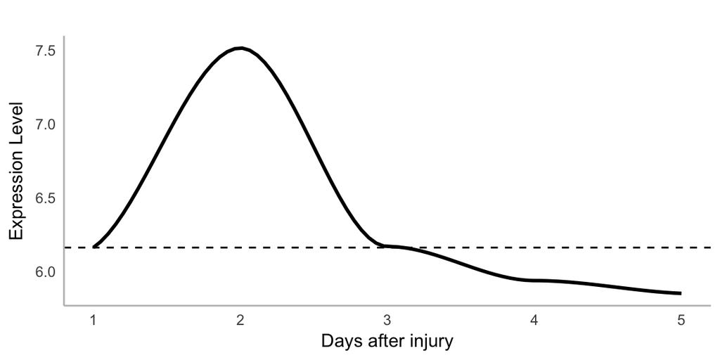

```r
library(ggplot2)
ggplot(dfave,aes(x = time,y = avelog2)) +
  geom_smooth(color="black") + #拟合曲线的颜色
  labs(x = "Days after injury", y = "Expression Level", title = "") +
  theme_bw() + #去除背景色
  theme(panel.grid =element_blank()) + #去除网格线
  theme(panel.border = element_blank()) + #去除外层边框
  theme(axis.line = element_line(colour = "grey")) + #坐标轴画成灰色
  theme(axis.ticks = element_blank()) + #取掉坐标轴上的刻度线
  geom_hline(yintercept = dfave$avelog2[1],linetype="dashed") #在第一个时间点处画虚线
```